# CBDA with SuperLearner

Simeone Marino and Ivo Dinov

June 13, 2016

## Introduction

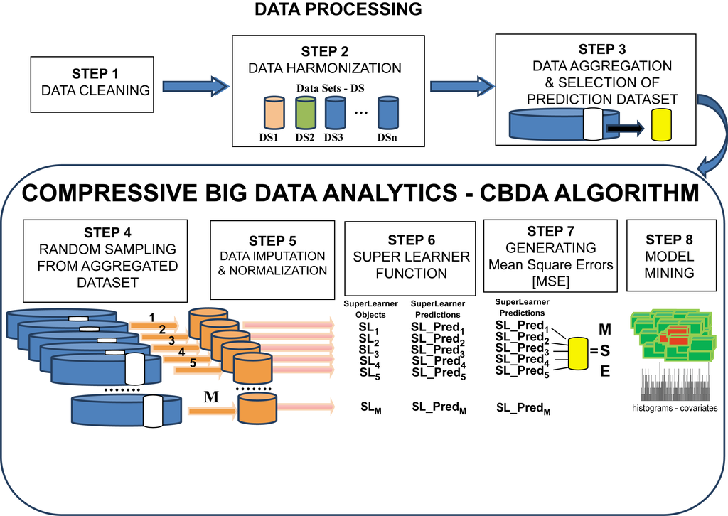

**Figure 1:** CBDA-SL flowchart

I embedded the R code chunks with all the comments below. The dataset that I used in this example is attached separately as a text file (i.e., NeuroIm1.txt).

```r
# Load a session
#load("~/Documents/NIH-grant/SOCR/CBDA_v0.RData")

# Set the working directory
#setwd("~/R")
setwd("~/Documents/NIH-grant/SOCR")

## STEP 1 - DATA CLEANING
## This is just an example with the MRI dataset "NeuroIm1.txt"
NeuroIm1 = read.table("NeuroIm1.txt", header = TRUE)

# Delete the last 3 columns from the big matrix NeurIm1 ["ROI","Measure","Value"]
# and store the rest in a temp matrix, compressing unique values by patients
NeuroIm1_Fix <- unique(NeuroIm1[,-1*(11:13)])
#length(unique(NeurIm1_Fix))

# Define Variables/Columns: Patients, type of Measures and ROI [Region of Interest]
Patients <- NeuroIm1_Fix$Subject_ID
Measures <- c("SA","SI","CV","FD")
ROI <- unique(NeuroIm1$ROI)
# Initialize a new data matrix that has the correct # of columns
NeuroIm1_NEW = array(0, c(length(Patients), length(ROI)*length(Measures)))
## We assign names to the columns in the form of Value_Measure_ROI
```

```r
names = NULL
for (j in 1:length(Measures)) {
  for (i in 1:length(ROI))
    names = c(names, paste("Value",Measures[j], ROI[i],"END", sep="_"))
}
#length(names)
#dim(NeuroIm1_NEW)
names(NeuroIm1_NEW) <- names
```

```r
# This loops extract a record from the big dataset, matching patient id, type of measure and ROI.
# Then It looks at the columns of the expanded matrix (# columns = Measures x ROI), and selects
# the column that matches the label resulting by combining Measures and ROI values in the record.
# Then it retries the value in the Value field of the big matrix and place it in the expanded matrix
# at the selected column

for (i in 1:length(Patients)) {
  for (j in 1:length(Measures)) {
    for (s in 1:length(ROI)) {
      NeuroIm1_temp = NeuroIm1[NeuroIm1$Subject_ID==i & NeuroIm1$Measure==Measures[j] & NeuroIm1$ROI==ROI[s],]
      a = paste(c("Value_",Measures[j],"_",ROI[s],"_END"),collapse="")
      b = which(names(NeuroIm1_NEW)==a)
      NeuroIm1_NEW[i,b] <- NeuroIm1_temp$Value
    }
  }
}

# Appends the matrix that is fixed from the big matrix to the expanded one.
# The final dimension of this matrix is rows=# patients
# This is the matrix to use for the analysis with SuperLearner, after few more
# data cleaning and recasting.
# List of libraries/packages needed below
library("colorspace")
library("grid")
library("data.table")
library("VIM")
library(MASS)
library(Matrix)
library(lme4)
library(arm)
library(foreach)
library(glmnet)
library(class)
library(nnet)

NeuroIm1_Final <- cbind(NeuroIm1_Fix, NeuroIm1_NEW)
# Set the names/labes of the columns
names(NeuroIm1_Final) <- c(names(NeuroIm1_Fix),names)

# Normalization of the aggregated matrix without Group and Sex
# This step will need to be moved within the SuperLearner loop,
# at the same time when IMPUTATION is performed on each subset of the
# aggregated matrix
a1 = which(names(NeuroIm1_Final) == "Group")
a2 = which(names(NeuroIm1_Final) == "Sex")

cont = 1:length(NeuroIm1_Final)
cont <- cont[-1*c(a1,a2)]
```

```r
NeuroIm1_Final[,cont] <- data.frame(apply(NeuroIm1_Final[,cont], 2, function(x)
{x <- rescale(x, "full")}));
rm(cont)
```

```r
# Recast the binary variable Sex
NeuroIm1_Final$Sex <- ifelse(NeuroIm1_Final$Sex=="F",1,0)

## Generating binary outcome matrices and relabeling categorical variables
## SINCE WE HAVE 3 GROUPS: AD-aLZHEIMER, MCI=MINOR COGNITIVE IMPAIRMENT, NC=NORMAL
NeuroIm1_Final_AD = NeuroIm1_Final[NeuroIm1_Final$Group == "AD",]
NeuroIm1_Final_NC = NeuroIm1_Final[NeuroIm1_Final$Group == "NC",]
NeuroIm1_Final_MCI = NeuroIm1_Final[NeuroIm1_Final$Group == "MCI",]

# Merge the datasets for training. I am defining 3 datsets here to be used for training
# since the SUperLearner function only works with binomial outcomes (for now).
# We will test SL comparing AD vs NC
NeuroIm1_Final_AD_vs_NC_training = rbind(NeuroIm1_Final_AD,NeuroIm1_Final_NC) # This is our aggregated dataset !!
NeuroIm1_Final_AD_vs_MCI_training = rbind(NeuroIm1_Final_AD,NeuroIm1_Final_MCI)
NeuroIm1_Final_NC_vs_MCI_training = rbind(NeuroIm1_Final_NC,NeuroIm1_Final_MCI)

# Labels the columns of the new matrices
names(NeuroIm1_Final_AD_vs_NC_training) <- c(names(NeuroIm1_Fix),names)
names(NeuroIm1_Final_AD_vs_MCI_training) <- c(names(NeuroIm1_Fix),names)
names(NeuroIm1_Final_NC_vs_MCI_training) <- c(names(NeuroIm1_Fix),names)

# Defining and recasting the binary variable Group for each dataset
NeuroIm1_Final_AD_vs_NC_training$Group <- ifelse(NeuroIm1_Final_AD_vs_NC_training$Group=="AD",1,0)
NeuroIm1_Final_AD_vs_MCI_training$Group <- ifelse(NeuroIm1_Final_AD_vs_MCI_training$Group=="AD",1,0)
NeuroIm1_Final_NC_vs_MCI_training$Group <- ifelse(NeuroIm1_Final_NC_vs_MCI_training$Group=="MCI",1,0)

# Define the temporary output [Ytemp] and input [Xtemp] matrices for the SuperLearner call
Xtemp = NeuroIm1_Final_AD_vs_NC_training; # temporary X-->Xtemp to modify and pass to SuperLearner
#Xtemp = NeuroIm1_Final_AD_vs_MCI_training;
#Xtemp = NeuroIm1_Final_MCI_vs_NC_training;
#Xnew = NeuroIm1_Final_AD_vs_NC_test; # temporary X-->Xtemp to modify and pass to SuperLearner

# assign the Group column to the output Y
Ytemp = NeuroIm1_Final_AD_vs_NC_training$Group; # Output Matrix Y for SuperLearner
#Y = NeuroIm1_Final_AD_vs_MCI_training$Group; # Output Matrix Y for SuperLearner
#Y = NeuroIm1_Final_MCI_vs_NC_training$Group; # Output Matrix Y for SuperLearner

# Select the columns Patient ID [1], MMSE [3]  (Mini-Mental State Exam score, a cognitive assessment measure),
# and CDR [4] (Clinical Dementia Rating scale from the test dataset X)[Group]
# and eliminate them from the training dataset because almost perfectly correlated to Y
w = which(names(NeuroIm1_Final_AD_vs_NC_training) == "Subject_ID" | names(NeuroIm1_Final_AD_vs_NC_training) == "Group" |
            names(NeuroIm1_Final_AD_vs_NC_training) == "MMSE" | names(NeuroIm1_Final_AD_vs_NC_training) == "CDR")
names(Xtemp)
```

```
##   [1] "Subject_ID"      "Group"           "MMSE"
##   [4] "CDR"             "Sex"             "Age"
##   [7] "TBV"             "GMV"             "WMV"
##  [10] "CSFV"            "Value_SA_1_END"  "Value_SA_2_END"
##  [13] "Value_SA_3_END"  "Value_SA_4_END"  "Value_SA_5_END"
##  [16] "Value_SA_6_END"  "Value_SA_7_END"  "Value_SA_8_END"
##  [19] "Value_SA_9_END"  "Value_SA_10_END" "Value_SA_11_END"
##  [22] "Value_SA_12_END" "Value_SA_13_END" "Value_SA_14_END"
##  [25] "Value_SA_15_END" "Value_SA_16_END" "Value_SA_17_END"
##  [28] "Value_SA_18_END" "Value_SA_19_END" "Value_SA_20_END"
##  [31] "Value_SA_21_END" "Value_SA_22_END" "Value_SA_23_END"
##  [34] "Value_SA_24_END" "Value_SA_25_END" "Value_SA_26_END"
##  [37] "Value_SA_27_END" "Value_SA_28_END" "Value_SA_29_END"
##  [40] "Value_SA_30_END" "Value_SA_31_END" "Value_SA_32_END"
##  [43] "Value_SA_33_END" "Value_SA_34_END" "Value_SA_35_END"
```

[output cut: 63 more lines]

```r
Xtemp <- Xtemp[,-1*w] # Eliminate the output column (Group) from the training dataset X
names(Xtemp)
```

```
##   [1] "Sex"             "Age"             "TBV"
##   [4] "GMV"             "WMV"             "CSFV"
##   [7] "Value_SA_1_END"  "Value_SA_2_END"  "Value_SA_3_END"
##  [10] "Value_SA_4_END"  "Value_SA_5_END"  "Value_SA_6_END"
##  [13] "Value_SA_7_END"  "Value_SA_8_END"  "Value_SA_9_END"
##  [16] "Value_SA_10_END" "Value_SA_11_END" "Value_SA_12_END"
##  [19] "Value_SA_13_END" "Value_SA_14_END" "Value_SA_15_END"
##  [22] "Value_SA_16_END" "Value_SA_17_END" "Value_SA_18_END"
##  [25] "Value_SA_19_END" "Value_SA_20_END" "Value_SA_21_END"
##  [28] "Value_SA_22_END" "Value_SA_23_END" "Value_SA_24_END"
##  [31] "Value_SA_25_END" "Value_SA_26_END" "Value_SA_27_END"
##  [34] "Value_SA_28_END" "Value_SA_29_END" "Value_SA_30_END"
##  [37] "Value_SA_31_END" "Value_SA_32_END" "Value_SA_33_END"
##  [40] "Value_SA_34_END" "Value_SA_35_END" "Value_SA_36_END"
##  [43] "Value_SA_37_END" "Value_SA_38_END" "Value_SA_39_END"
```

[output cut: 62 more lines]

```r
## SAMPLE THE PREDICTION DATASET
# Fraction (SET TO 15% BELOW) of data/patients to use for prediction, IN A BALANCED WAY
alpha=0.15
a1=round(length(which(Ytemp==1))*alpha);
a2=round(length(which(Ytemp==0))*alpha);
# selects randomly patients for prediction
q1 = sample(which(Ytemp==1),a1)
q2 = sample(which(Ytemp==0),a2)
q <- c(q1 , q2)
Xnew <- as.data.frame(Xtemp[q,]) # define the patients to predict
Xtemp <- Xtemp[-1*q,] # eliminate q patients for prediction [not used in the training]
Ypred <- Ytemp[q] # assign the output for the prediction set [not used in the training]
Ytemp <- Ytemp[-1*q] # eliminate q patients for prediction [not used in the training]

# SET THE SAME NAMES/LABELS FOR THE NEW MATRIX Xnew
names(Xnew) <- names(Xtemp)
```

```r
## STEP 5 - SUPERLEARNER FUNCTION LOOP (TRAINING/VALIDATION): M,K and N
## LIBRARIES/PACKAGES NEEDED FOR THE SUPERLEARNER LOOP
library(nnls)
library(SuperLearner)
library(plotrix)
library(TeachingDemos)
library(plotmo)
library(earth)
library(parallel)
library(splines)
library(gam)
library(foreach)
```

```r
# Specify new SL prediction algorithm wrappers #
# I CAN EXPLAIN THIS STEP (wrappers) IN MORE DETAIL
SL.glmnet.0 <- function(..., alpha = 0){
  SL.glmnet(..., alpha = alpha)
} # ridge penalty
SL.library <- c("SL.glm","SL.gam","SL.glmnet","SL.glmnet.0")

M=100; # This is the number of random subsets of the big dataset [from 1e2 to 1e5] to perform SuperLearner on
coordSL=dim(Xtemp)
N=coordSL[1]
K=coordSL[2]


## SUPERLEARNER LOOP
for(j in seq(1:M)) {
  Kcol <- round(K*runif(1,0.15,0.3)) # sample a value from a uniform distribution within 0.01 and 0.1 [number of columns/covariates between 10-30% of the big dataset]
  Nrow <- round(N*runif(1,0.6,0.8)) # sample a value from a uniform distribution within 0.6 and 0.8 [number of rows/subjects between 60-80% of the big dataset]
  #Nrow <- N # this option will NOT sample subjects/rows, it will include them all
  k <- sample(1:K,Kcol) # this is where I generate the sample of columns
  n <- sample(1:N,Nrow) # this is where I generate the sample of columns
  # Automated labeling of sub-matrices, assigned to X
  eval(parse(text=paste0("X",j," <- as.data.frame(Xtemp[,k])")))
  eval(parse(text=paste0("X",j," <- as.data.frame(dplyr::slice(X",j,",n))")))
  eval(parse(text=paste0("X <- X",j)))
  eval(parse(text=paste0("Y",j," <- Ytemp[n]")))
  eval(parse(text=paste0("Y <- Y",j)))

  eval(parse(text=paste0("k",j," <- k")))
  eval(parse(text=paste0("n",j," <- n")))

  ## STEP 6 - DATA IMPUTATION AND NORMALIZATION
  # EMPTY NOW, no missing data, WILL FILL IN WITH A MOCK FUNCTION FOR IMPUTATION
  # NO NORMALIZATION BECAUSE ALREADY PERFORMED ABOVE ON THE AGGREGATED DATASET
  # THE SAME CALL ON LINES 83-86 WILL BE USED HERE

  # SUPERLEARNER-SL FUNCTION CALL that generates SL objects
  SL <- SuperLearner(Y,X,#Xnew[,1:K],
                           family=binomial(),
                           SL.library=SL.library,
                           method="method.NNLS",
                           verbose = TRUE,
                           control = list(saveFitLibrary = TRUE),
                           cvControl = list(V=10));
    eval(parse(text=paste0("SL_",j," <- SL")));
}
```

```r
    # Generates SL_Pred objects using the predict function on the prediction
    # dataset with the SL object as the predictive model.
    # SL_Pred returns both the SuperLearner predictions ("pred") and
    # predictions for each algorithm in the library (SL.library above)
for(j in seq(1:M)) {
  eval(parse(text=paste0("SL_Pred_",j," <- predict(SL_",j,", Xnew[,k",j,"])")))
}

# Test if all the k are generated throughout the SuperLearner loop
for (j in seq(1:M)){
  j
  eval(parse(text=paste0("k",j)))
  }
```

At the end of STEPS 5-6, i.e. the SuperLearner loop, we have: i) Set of M SuperLearner-SL objects labeled as SL_j (j from 1 to M) ii) Set of M kj (subset of covariates passed to the SuperLearner function, j from 1 to M) iii) Set of M nj (subset of patients/subjects passed to the SuperLearner function, j from 1 to M)

The code below generates Mean Square Error-MSE between the prediction returned on the external dataset Xnew and the actual testset values. Then it ranks all the MSE. Based on the ranking, the covariates of the top predictions are listed and the common subsets is selected. The common subset of covariates gives an idea of the covariates that are most relevant for the best predictions (i.e., predictions with the lowest MSE). A sequence of histograms is generated below by cumulating the prediction rankings. NOTE: I need to “normalize” the frequencies in the histograms so the y axis is fixed.

```r
## STEP 7 - GENERATING MSE
## MSE obtained by looping through the predictions made on the external dataset of q patients
## using the SuperLearner prediction algorithm output [SL_Pred_j], with the Xnew
## matrix of the appropriate subset of covariates kj
Ynew = NeuroIm1_Final_AD_vs_NC_training$Group[q];
sum=0
for (j in 1:M) {
  for(i in 1:length(Ynew)) {
    eval(parse(text=paste0("sum <- sum(Ynew[",i,"] - SL_Pred_",j,"$pred[",i,"])^2")))
    }
  eval(parse(text=paste0("MSE_",j," <- sum/length(Ynew)")))
  sum = 0;
}
## STEP 7 - RANKING MSE
## MSE obtained by looping through the predictions made on the external dataset of q patients
## using the SuperLearner prediction algorithm output [SL_Pred_j], with the Xnew
## matrix of the appropriate subset of covariates kj

#  GENERATING THE ARRAY OF MSE FOR ALL THE M SL OBJECTS
MSE=0;
for (j in 1:M) {
  eval(parse(text=paste0("MSE[j] <- MSE_",j)))
}
```

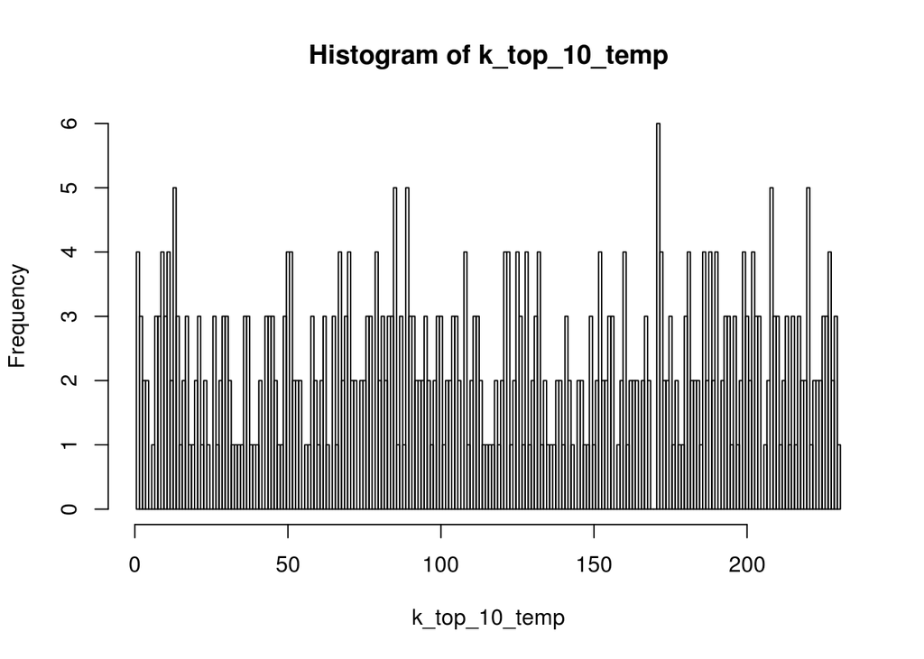

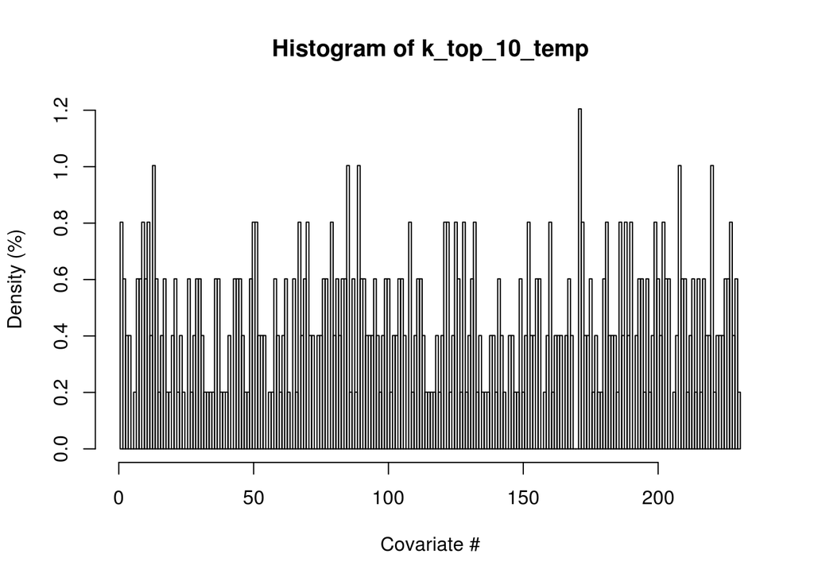

```
## Press <return to continue
```

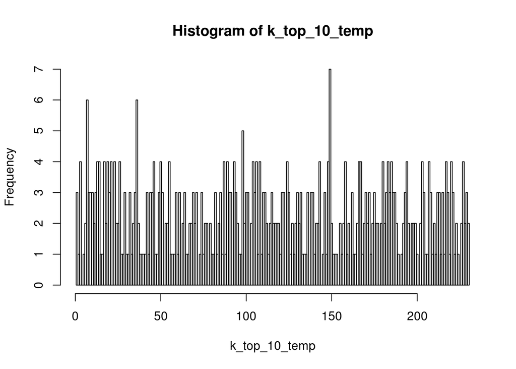

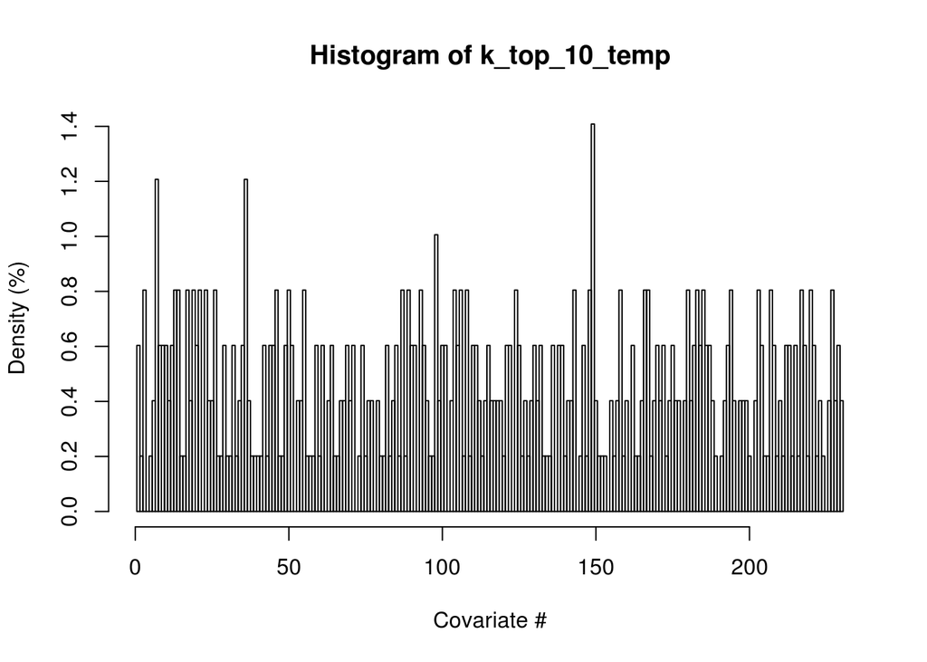

```
## Press <return to continue
```

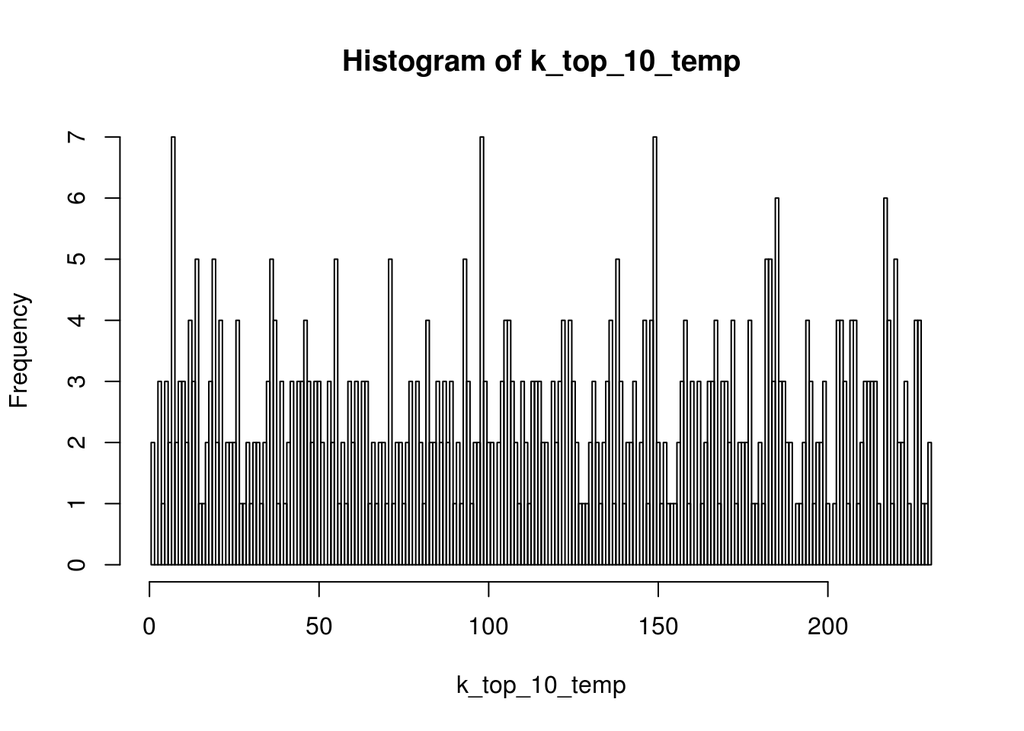

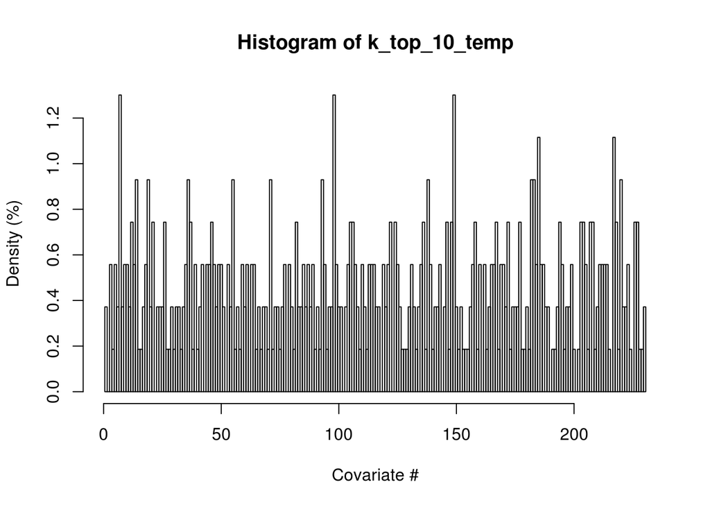

```
## Press <return to continue
```

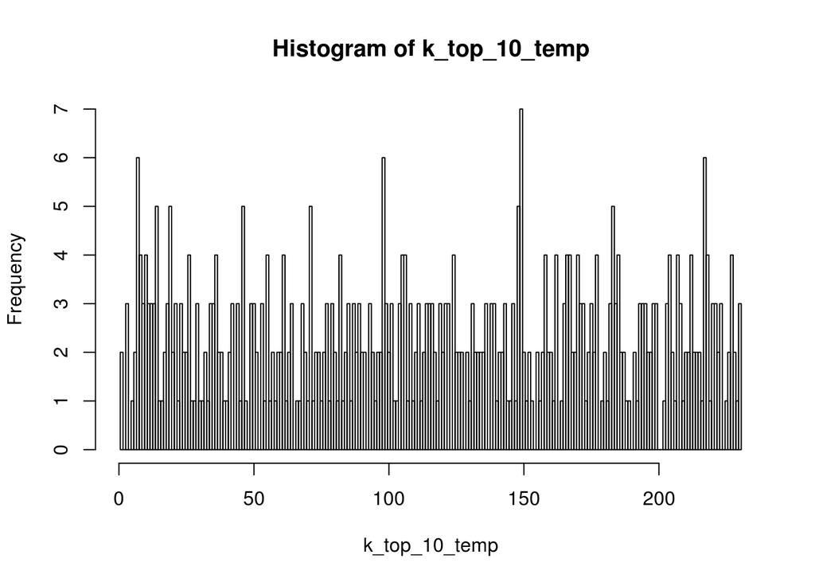

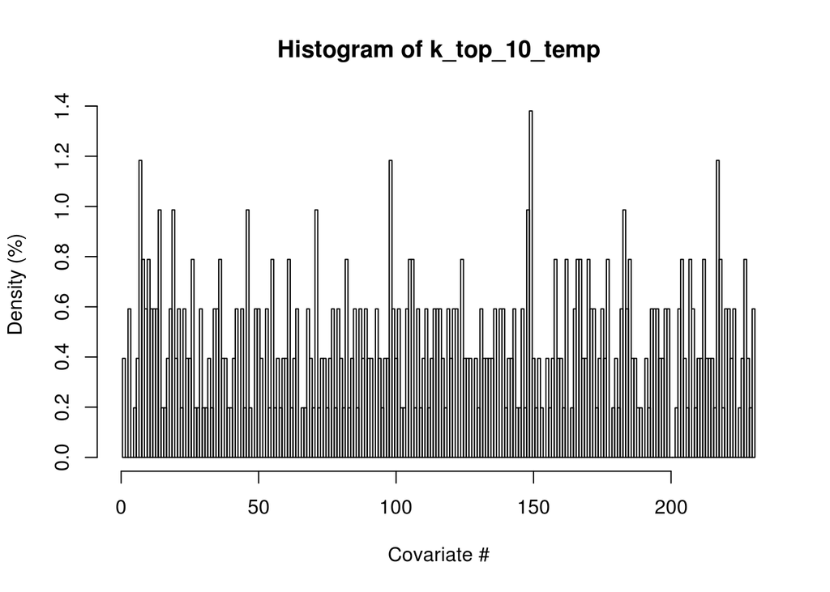

```
## Press <return to continue
```

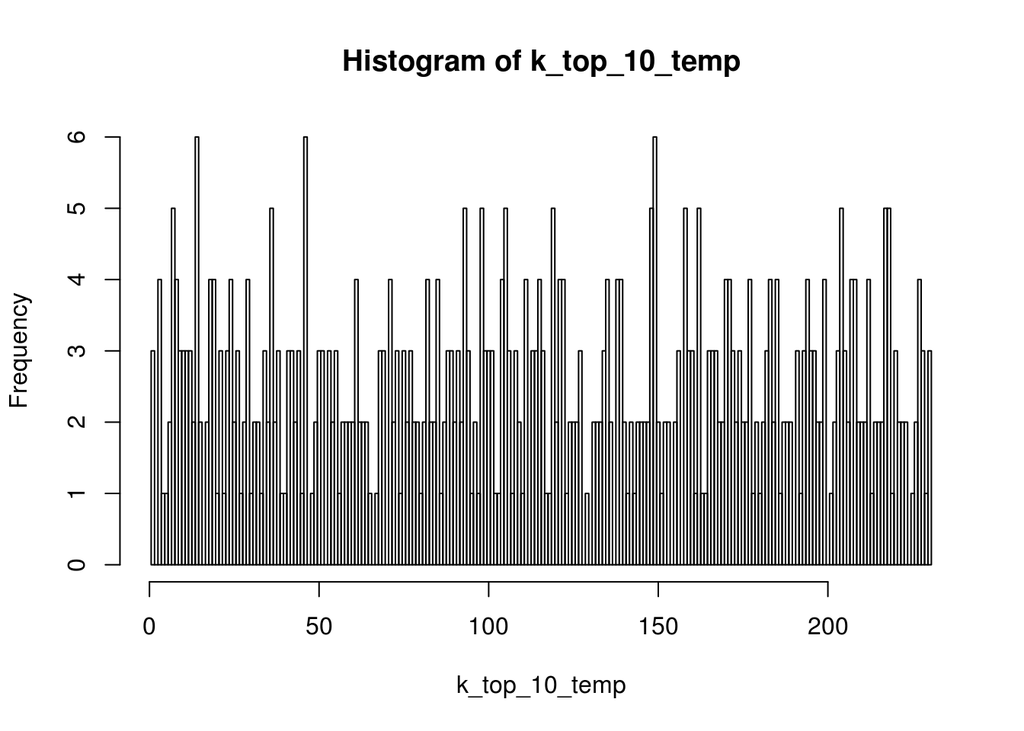

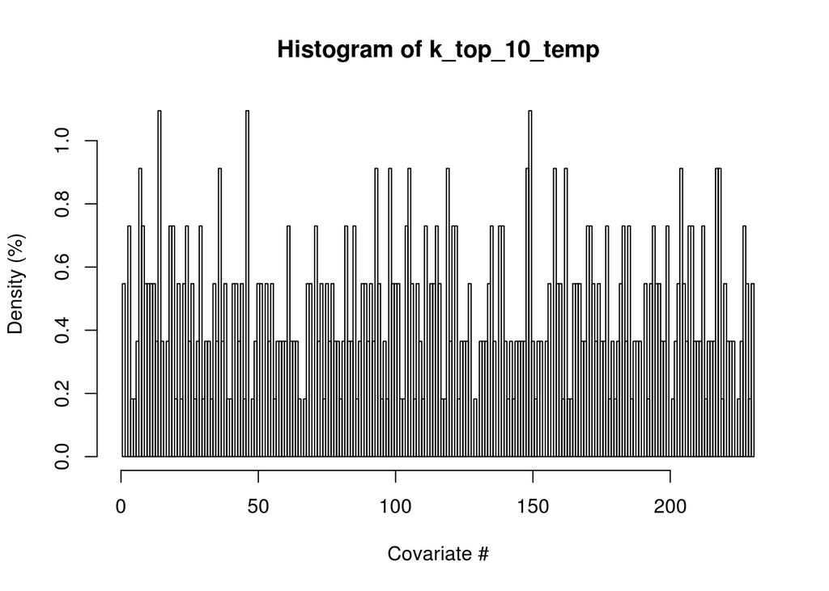

```
## Press <return to continue
```

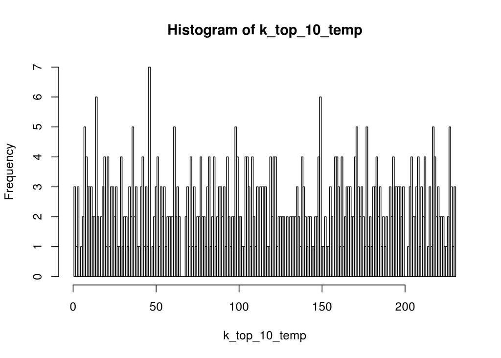

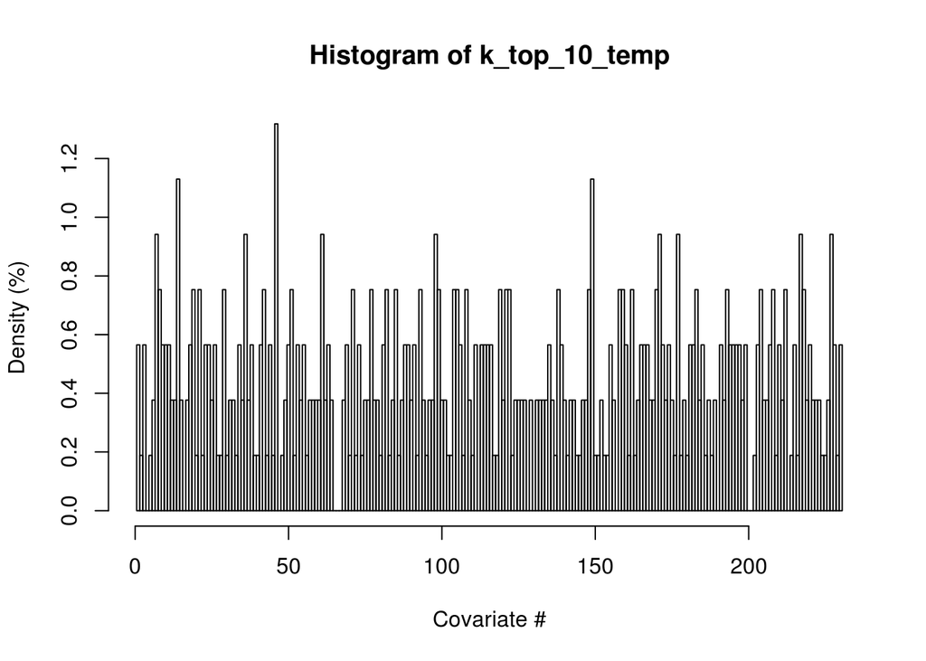

```
## Press <return to continue
```

[8 more figures not shown]

```
## Press <return to continue
```

```r
for (s in seq(10,M,10)){
  MSE_temp <- NULL
  MSE_sorted_temp <- NULL
  #MSE_temp <- data.table(mse=MSE[1:s],rank=1:s)
  MSE_temp <- data.frame(mse=MSE[1:s],rank=1:s)
  #MSE_sorted_temp <- setorder(MSE_temp, mse,-rank)
  #MSE_sorted_temp <- sort(MSE_temp, mse,-rank)
  MSE_sorted_temp <- MSE_temp[order(MSE_temp$mse),]
  ## DEFINE HERE THE TOP # OF COVARIATES TO LIST in the MODEL MINING STEP
  top = 10;
  eval(parse(text=paste0("k_top_",top,"_temp <- NULL")))
  for (i in 1:top){
      eval(parse(text=paste0("k_top_",top,"_temp <- c(k_top_",top,"_temp, k",MSE_sorted_temp$rank[i],")")))
    }
  ## STEP 8 - MODEL MINING (HISTOGRAMS OF TOP 20 or 50 COVARIATES)
  # GENERATE HISTOGRAMS OF THE TOP # OF COVARIATES
  eval(parse(text=paste0("x = k_top_",top,"_temp")))
  #h = hist(x)
  eval(parse(text=paste0("h = hist(k_top_",top,"_temp,breaks=seq(min(k_top_",top,"_temp)-0.5,max(k_top_",top,"_temp)+0.5, by=1))")))
  #eval(parse(text=paste0("hist(k_top_",top,"_temp, breaks=seq(min(k_top_",top,"_temp)-0.5, max(k_top_",top,"_temp)+0.5, by=1))")))
  h$density = h$counts/sum(h$counts)*100
  plot(h,freq=FALSE,ylab='Density (%)',xlab='Covariate #')
  readline("Press <return to continue")
}
```